# ✍ Student: Mohammad Osmanpoor

# Task 2: Ordinary linear regression model on multi-dimensional features/variables

```python
# Data preparation
X = data[['area', 'bedroom']].values
y = data['price'].values
```

Split data into training and testing sets

```python
# Split data into training and testing sets (80% train, 20% test)
X_train, X_test, y_train, y_test = ms.train_test_split(X, y, test_size=0.2, random_state=42)
```

Build linear regression model

```python
model = lm.LinearRegression()
model.fit(X_train, y_train)
```

```
LinearRegression()
```

Check model coefficients and comment

```python
print("Coefficients:", model.coef_)
print("Intercept:", model.intercept_)
```

```
Coefficients: [   143.21853204 -13512.56442597]
Intercept: 84763.62252219388
```

✍ comment: The coefficients we can see (one per feature) indicate the incremental price change per unit increase in area or number of bedrooms, while the intercept represents the baseline price.

Do model predictions on test set

```python
y_pred = model.predict(X_test)
```

Get model scores in terms of MSE and $r^2$ scores

```python
mse = mean_squared_error(y_test, y_pred)
r2 = r2_score(y_test, y_pred)


print("Mean Squared Error:", mse)
print("Coefficient of Determination (R^2):", r2)
```

```
Mean Squared Error: 8610424544.777676
Coefficient of Determination (R^2): 0.5148848812741439
```

# Task 3: Nearest neighbors based classification

Data preprocessing

```python
# Import the commonly-used modules
import pandas as pd
import numpy as np

# Load the dataset
data = pd.read_csv("titanic.csv")
print("data size: "+str(data.shape))
data.head()
```

```
data size: (891, 12)
```

|  | PassengerId | Name | Sex | Age | SibSp | Parch | Ticket | Fare | Cabin | Embarked | Pclass | Survived |
| --- | --- | --- | --- | --- | --- | --- | --- | --- | --- | --- | --- | --- |
| 0 | 1 | Braund, Mr. Owen Harris | male | 22.0 | 1 | 0 | A/5 21171 | 7.2500 | NaN | S | 3 | 0 |
| 1 | 2 | Cumings, Mrs. John Bradley (Florence Briggs Th... | female | 38.0 | 1 | 0 | PC 17599 | 71.2833 | C85 | C | 1 | 1 |
| 2 | 3 | Heikkinen, Miss. Laina | female | 26.0 | 0 | 0 | STON/O2. 3101282 | 7.9250 | NaN | S | 3 | 1 |
| 3 | 4 | Futrelle, Mrs. Jacques Heath (Lily May Peel) | female | 35.0 | 1 | 0 | 113803 | 53.1000 | C123 | S | 1 | 1 |
| 4 | 5 | Allen, Mr. William Henry | male | 35.0 | 0 | 0 | 373450 | 8.0500 | NaN | S | 3 | 0 |

```python
# size of the data
print("(row, column):",data.shape)
```

```
(row, column): (891, 12)
```

```python
# check for missing values
data.isnull().sum()
```

|  | 0 |
| --- | --- |
| PassengerId | 0 |
| Name | 0 |
| Sex | 0 |
| Age | 177 |
| SibSp | 0 |
| Parch | 0 |
| Ticket | 0 |
| Fare | 0 |
| Cabin | 687 |
| Embarked | 2 |
| Pclass | 0 |
| Survived | 0 |

**dtype:** int64

```python
# one option is to just simply drop rows with any missing values
data_no_missing_value=data.dropna()
print("(row, column) after dropping missing values:\n",data_no_missing_value.shape)
```

```
(row, column) after dropping missing values:
 (183, 12)
```

```python
# get one column from the data
data_name=data_no_missing_value["Name"]
data_name
```

|  | Name |
| --- | --- |
| 1 | Cumings, Mrs. John Bradley (Florence Briggs Th... |
| 3 | Futrelle, Mrs. Jacques Heath (Lily May Peel) |
| 6 | McCarthy, Mr. Timothy J |
| 10 | Sandstrom, Miss. Marguerite Rut |
| 11 | Bonnell, Miss. Elizabeth |
| ... | ... |
| 871 | Beckwith, Mrs. Richard Leonard (Sallie Monypeny) |
| 872 | Carlsson, Mr. Frans Olof |
| 879 | Potter, Mrs. Thomas Jr (Lily Alexenia Wilson) |
| 887 | Graham, Miss. Margaret Edith |
| 889 | Behr, Mr. Karl Howell |

183 rows × 1 columns

**dtype:** object

```python
# get three columns from the data
data_sex_age_survived=data_no_missing_value[['Sex', 'Age', 'Survived']]
data_sex_age_survived
```

|  | Sex | Age | Survived |
| --- | --- | --- | --- |
| 1 | female | 38.0 | 1 |
| 3 | female | 35.0 | 1 |
| 6 | male | 54.0 | 0 |
| 10 | female | 4.0 | 1 |
| 11 | female | 58.0 | 1 |
| ... | ... | ... | ... |
| 871 | female | 47.0 | 1 |
| 872 | male | 33.0 | 0 |
| 879 | female | 56.0 | 1 |
| 887 | female | 19.0 | 1 |
| 889 | male | 26.0 | 1 |

183 rows × 3 columns

```python
# encode categorical attributes
data_sex_age_survived['Sex']=data_sex_age_survived.Sex.astype('category').cat.codes
data_sex_age_survived
```

|  | Sex | Age | Survived |
| --- | --- | --- | --- |
| 1 | 0 | 38.0 | 1 |
| 3 | 0 | 35.0 | 1 |
| 6 | 1 | 54.0 | 0 |
| 10 | 0 | 4.0 | 1 |
| 11 | 0 | 58.0 | 1 |
| ... | ... | ... | ... |
| 871 | 0 | 47.0 | 1 |
| 872 | 1 | 33.0 | 0 |
| 879 | 0 | 56.0 | 1 |
| 887 | 0 | 19.0 | 1 |
| 889 | 1 | 26.0 | 1 |

183 rows × 3 columns

Build model and perform evaluation

```python
# define X and y
feature_columns=['Sex', 'Age']
X=data_sex_age_survived[feature_columns]
y=data_sex_age_survived.Survived
print(X.head())
print(y.head())
```

```
    Sex   Age
1     0  38.0
3     0  35.0
6     1  54.0
10    0   4.0
11    0  58.0
1     1
3     1
6     0
10    1
11    1
Name: Survived, dtype: int64
```

```python
# train/test data split
from sklearn.model_selection import train_test_split
X_train, X_test, y_train, y_test = train_test_split(X, y)
```

```python
# train a 1-NN classifier
from sklearn import neighbors
clf = neighbors.KNeighborsClassifier(n_neighbors=1)
clf.fit(X_train, y_train)
```

```
KNeighborsClassifier(n_neighbors=1)
```

```python
# predict the test data
y_pred=clf.predict(X_test)
y_pred
```

```
array([0, 0, 1, 1, 1, 0, 1, 0, 1, 0, 1, 0, 1, 1, 0, 1, 1, 1, 0, 1, 0, 0,
       0, 1, 0, 0, 0, 1, 1, 1, 1, 0, 0, 1, 1, 0, 0, 1, 0, 1, 0, 1, 1, 1,
       1, 0])
```

```python
# calculate testing accuracy
from sklearn import metrics
print(metrics.accuracy_score(y_test, y_pred))
```

```
0.717391304347826
```

## Now, let's do the task

```python
# Load the dataset
data = pd.read_csv("titanic.csv")
print("data size: "+str(data.shape))
data.head()
```

```
data size: (891, 12)
```

|  | PassengerId | Name | Sex | Age | SibSp | Parch | Ticket | Fare | Cabin | Embarked | Pclass | Survived |
| --- | --- | --- | --- | --- | --- | --- | --- | --- | --- | --- | --- | --- |
| 0 | 1 | Braund, Mr. Owen Harris | male | 22.0 | 1 | 0 | A/5 21171 | 7.2500 | NaN | S | 3 | 0 |
| 1 | 2 | Cumings, Mrs. John Bradley (Florence Briggs Th... | female | 38.0 | 1 | 0 | PC 17599 | 71.2833 | C85 | C | 1 | 1 |
| 2 | 3 | Heikkinen, Miss. Laina | female | 26.0 | 0 | 0 | STON/O2. 3101282 | 7.9250 | NaN | S | 3 | 1 |
| 3 | 4 | Futrelle, Mrs. Jacques Heath (Lily May Peel) | female | 35.0 | 1 | 0 | 113803 | 53.1000 | C123 | S | 1 | 1 |
| 4 | 5 | Allen, Mr. William Henry | male | 35.0 | 0 | 0 | 373450 | 8.0500 | NaN | S | 3 | 0 |

```python
# delete the attribute "Cabin"
del data['Cabin']
```

```python
# fill missing values with the mean age
print("The mean age: ", data.Age.mean())


# fill missing 'Age' values with the mean age
data['Age'].fillna(data['Age'].mean(), inplace=True)
```

```
The mean age:  29.64209269662921
```

```python
# drop rows with any missing values (the "Embarked" atrribute)
data.dropna(subset=['Embarked'], inplace=True)
```

## ⚠ the below code that you have written in original notebook, not work and throw and error, becase we don't have any declaration for `df` dataframe. so for this reason i commented out it and wrote my own code

```python
# # "PassengerId", "Name" and "Ticket" are not suitable for features. Select all other attributes to form a data set.
# feature_cols = ['Sex', 'Age', 'Embarked', 'Pclass', 'Fare', 'SibSp', 'Parch']
# X=df[feature_cols]
# y=df.Survived
# print(X.shape)
# print(y.shape)
```

```python
# Select feature columns and target variable
feature_cols = ['Sex', 'Age', 'Embarked', 'Pclass', 'Fare', 'SibSp', 'Parch']
X = data[feature_cols]
y = data['Survived']
```

```python
from sklearn.model_selection import train_test_split, cross_val_score, GridSearchCV
from sklearn.neighbors import KNeighborsClassifier
from sklearn.metrics import accuracy_score, classification_report
from sklearn.preprocessing import LabelEncoder
```

```python
# encode the categorical attributes where applicable
# encode categorical attributes: 'Sex' and 'Embarked'
le_sex = LabelEncoder()
X['Sex'] = le_sex.fit_transform(X['Sex'])


le_embarked = LabelEncoder()
X['Embarked'] = le_embarked.fit_transform(X['Embarked'])
```

```python
# build a 1-NN classification model where "Survived" is the prediction target

# Split data into training and testing sets
X_train, X_test, y_train, y_test = train_test_split(X, y, test_size=0.2, random_state=42)

# part 1: Build a 1-NN Classifier ...
knn = KNeighborsClassifier(n_neighbors=1)
knn.fit(X_train, y_train)
y_pred = knn.predict(X_test)
print("Accuracy of 1-NN:", accuracy_score(y_test, y_pred))
```

```
Accuracy of 1-NN: 0.6797752808988764
```

## More advanced tasks

Manually try other k values, e.g., 2, 3, 5, 10, the accuracy comparison

Hints: Put all values of k in a list. For each value of k instantiate a KNN classifier, and show its accuracy with a plot.

```python
# part 2: Compare Different k Values ...
k_values = [1, 2, 3, 5, 7, 9, 10]
accuracies = []

for k in k_values:
    knn_temp = KNeighborsClassifier(n_neighbors=k)
    knn_temp.fit(X_train, y_train)
    y_pred_k = knn_temp.predict(X_test)
    acc = accuracy_score(y_test, y_pred_k)
    accuracies.append(acc)
    print(f"k = {k}, Accuracy = {acc:.4f}")
```

```
k = 1, Accuracy = 0.6798
k = 2, Accuracy = 0.7135
k = 3, Accuracy = 0.7303
k = 5, Accuracy = 0.7022
k = 7, Accuracy = 0.7022
k = 9, Accuracy = 0.7247
k = 10, Accuracy = 0.7472
```

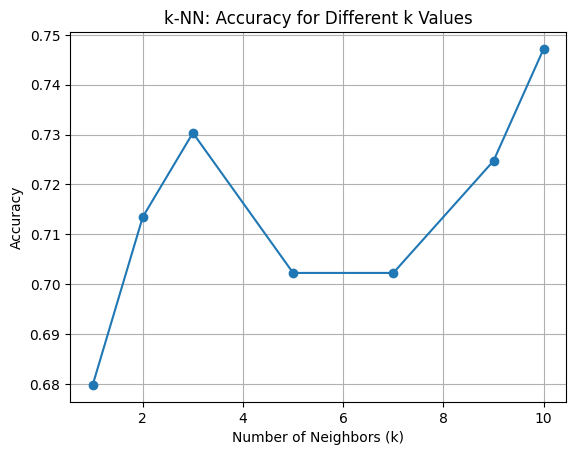

```python
# Plot accuracy versus different k values
plt.figure()
plt.plot(k_values, accuracies, marker='o')
plt.xlabel('Number of Neighbors (k)')
plt.ylabel('Accuracy')
plt.title('k-NN: Accuracy for Different k Values')
plt.grid(True)
plt.show()
```

Use 10-fold cross-validation (CV) for the kNN parameter k = 3. Output the mean and standard deviation of the accuracy for each fold.

Hint: To do this, make use of the cross_val_score function of sklearn.model_selection.

```python
# part 3: 10-Fold Cross-Validation for k=3 ...
knn_cv = KNeighborsClassifier(n_neighbors=3)
cv_scores = cross_val_score(knn_cv, X, y, cv=10)
print("10-fold CV scores for k=3:", cv_scores)
print("Mean CV Accuracy:", cv_scores.mean())
print("Standard Deviation:", cv_scores.std())
```

[output not shown]

Recall that the purpose of using a 10-fold, or in general k-fold, validation (note the k here is different from the k in kNN) is to choose the best hyperparameter. The hyperparameter here is k in kNN. That is we want to choose how many neighbors to consider. To do this we need to perform 10-fold cross validation over multiple values of k. Let us assume k = [1,2,3,5,7,9,10].

Lucikly the function GridSearchCV class from sklearn.model_selection can do this automatically for us. To use this class you need to pass the above values of k as parameters which is a dictionary construct. Please see the documentation of GridSearchCV on how to pass this for the kNN classifier.

What is the best parameter?

```python
# part 4: Hyperparameter Tuning with GridSearchCV ...
param_grid = {'n_neighbors': k_values}
grid_search = GridSearchCV(KNeighborsClassifier(), param_grid, cv=10)
grid_search.fit(X, y)
print("Best parameter from GridSearchCV:", grid_search.best_params_)
print("Best cross-validation accuracy:", grid_search.best_score_)
```

```
Best parameter from GridSearchCV: {'n_neighbors': 3}
Best cross-validation accuracy: 0.7165858018386109
```

✍ as we can see, the Cross-validation with k=3 gives an insight into model stability across different splits and it is our best hyperparameter value.

# Task 4: Build a decision tree model for the above classification task

Use DecisionTreeClassifier with default settings for this task. Output the accuracy or classification report.

Does decision tree classifier perform better than kNN?

```python
from sklearn.tree import DecisionTreeClassifier
from sklearn.metrics import classification_report

# Build a decision tree classifier (using the same train-test split from Task 3)
tree_clf = DecisionTreeClassifier(random_state=42)
tree_clf.fit(X_train, y_train)
y_pred_tree = tree_clf.predict(X_test)

# Evaluate the decision tree classifier
tree_accuracy = accuracy_score(y_test, y_pred_tree)
print("Decision Tree Accuracy:", tree_accuracy)
print("Classification Report for Decision Tree:")
print(classification_report(y_test, y_pred_tree))
```

```
Decision Tree Accuracy: 0.7528089887640449
Classification Report for Decision Tree:
              precision    recall  f1-score   support

           0       0.84      0.73      0.78       109
           1       0.65      0.78      0.71        69

    accuracy                           0.75       178
   macro avg       0.75      0.76      0.75       178
weighted avg       0.77      0.75      0.76       178
```

✍ Since the Decision Tree has a higher accuracy (75.28% vs. 71.66%), it performs better than kNN in terms of classification accuracy